# Establishing a Community of Practice

CCBR Code Club

Aug 26, 2025

## Agenda

- Establishing a Community of Practice with Code Clubs
- Tutorial on building docker containers

## Survey

Please fill out this survey if you haven’t already!

https://forms.gle/yT5LWko7LhAmGpZM6

## Recap

Journal club in February 2025

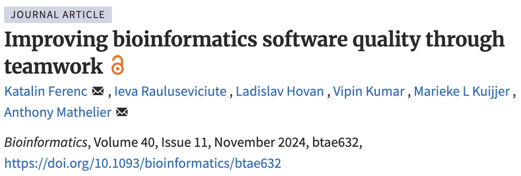

## Recap

[figure not shown]

*The improvement process in software dev is like rock climbing*

## Journal club for code

Just like a regular **journal club** seminar helps scientists keep up with the literature in their field, **code club** helps computational scientists keep up with best practices in software development.

Hagan et al. 2020. PLOS Comp Biol.

https://doi.org/10.1371/journal.pcbi.1008119

## Code Club as a community of practice

> Communities of practice are groups of people who share a concern or a passion for something they do and learn how to do it better as they interact regularly.

Wenger-Trayner, E. and Wenger-Trayner, B. 2015.

https://www.wenger-trayner.com/introduction-to-communities-of-practice.

## Goals of Code Club

- Adopt good practices in software development
- Improve the quality of our code
- Learn from each other
- Focus on CCBR-specific practices, ways of working

## Formats for code club

- Traditional powerpoint slides
- Live demos
- Hands-on activities
- Peer code review

Experimentation is encouraged!

## Resource Sharing

Code Club resources can be shared in the [CCBR HowTos repo](https://github.com/CCBR/HowTos).

- presentation slides
- tutorial documents
- links for further learning

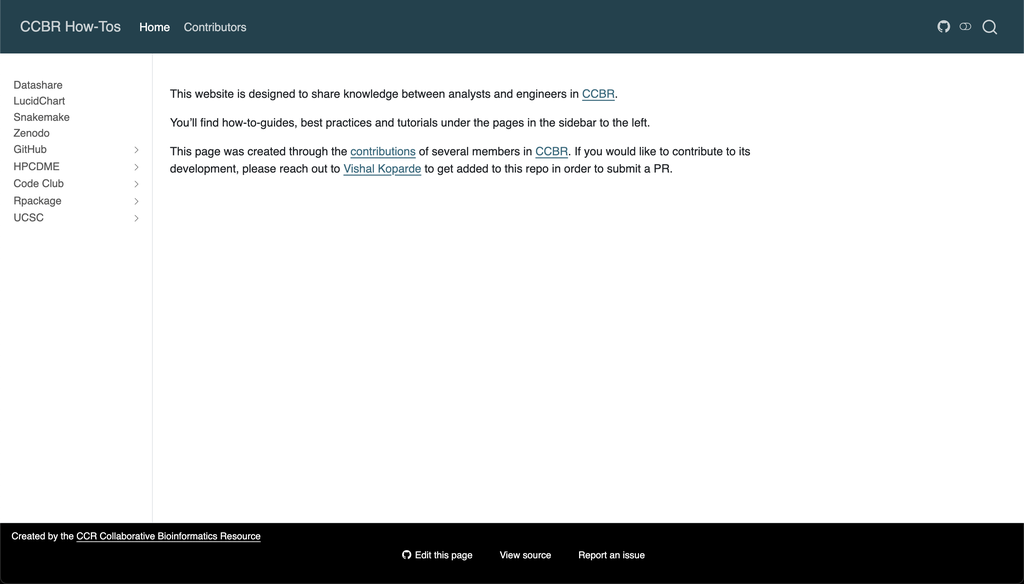

https://github.com/CCBR/HowTos

## Discussion

Questions, comments, suggestions?

## Next: docker tutorial